# Homework Assignment #1

**Your Name**:Jiwon MOk **Your G Number**: G01096224

In this homework assignment we will be focusing on data analysis and visualization with the `tidyverse`

# Load Packages and Data

The `R` code chunk below will load the `tidyverse` packages as well as an `auto_claims` data set.

```r
library(tidyverse)
auto_claims <- read_rds("~/https:/github.com/mason-sp22-cds101/ideal-jiwon/auto_claims.rds")
```

The `auto_claims` data contains information on auto accident claims processed by an insurance company in the western part of the United States.

Each row represents a claim made by a customer and includes customer demographics, their policy characteristics, monthly premium, vehicle information, claim amount, and [customer lifetime value](https://en.wikipedia.org/wiki/Customer_lifetime_value)

```r
auto_claims
```

```
## # A tibble: 6,249 x 17
##    customer_id customer_state highest_education employment_status gender income
##    <chr>       <fct>          <fct>             <fct>             <fct>   <dbl>
##  1 AA11235     Nevada         Bachelor          Medical Leave     Female  11167
##  2 AA16582     Washington     Bachelor          Medical Leave     Male    14072
##  3 AA34092     California     Associate         Employed          Male    33635
##  4 AA56476     Arizona        High School       Employed          Female  74454
##  5 AA69265     Nevada         Bachelor          Employed          Female  60817
##  6 AA71604     Arizona        Master            Employed          Female  87560
##  7 AA93585     California     Associate         Employed          Male    97024
##  8 AB21519     California     Associate         Employed          Female  93272
##  9 AB23825     California     Associate         Employed          Male    21509
## 10 AB26022     Oregon         High School       Retired           Male    26487
## # … with 6,239 more rows, and 11 more variables: residence_type <fct>,
## #   marital_status <fct>, sales_channel <fct>, coverage <fct>, policy <fct>,
## #   vehicle_class <fct>, vehicle_size <fct>, monthly_premium <dbl>,
## #   months_since_last_claim <dbl>, total_claim_amount <dbl>,
## #   customer_lifetime_value <dbl>
```

# Problem 1

Write one expression using dplyr functions and the %>% operator to create the summary table below, and arrange it based on the customer state.

**Hint**: You will need to create the `month_category` variable using `cut_width()` before you calculate the summaries by groups.

```r
library(dplyr)
auto_claims %>%
 mutate(month_category=cut_width(monthly_premium, width =12, boundary=0))%>%
  group_by(customer_state) %>%
  summarize(n_claims = total_claim_amount, avg_claim_amunt = mean(total_claim_amount), min_customer_lifetime_val = min(customer_lifetime_value), month_category)
```

```
## # A tibble: 6,249 x 5
## # Groups:   customer_state [5]
##    customer_state n_claims avg_claim_amunt min_customer_lifetime… month_category
##    <fct>             <dbl>           <dbl>                  <dbl> <fct>
##  1 Washington        1511.           1405.                  2227. [60,72]
##  2 Washington        1166.           1405.                  2227. [60,72]
##  3 Washington        1466.           1405.                  2227. (96,108]
##  4 Washington        1256.           1405.                  2227. (108,120]
##  5 Washington        1494.           1405.                  2227. (72,84]
##  6 Washington        1302.           1405.                  2227. [60,72]
##  7 Washington        1458            1405.                  2227. [60,72]
##  8 Washington        1508.           1405.                  2227. (72,84]
##  9 Washington        1416.           1405.                  2227. (132,144]
## 10 Washington        1468            1405.                  2227. [60,72]
## # … with 6,239 more rows
```

# Problem 2

Write one expression using dplyr functions and the %>% operator to create the summary table below.

This table contains the average, median, and maximum values of total_claim_amount by vehicle_class.

```r
auto_claims %>%
  group_by(vehicle_class)%>%
  summarise(min_amount = min(total_claim_amount), median_amount = median(total_claim_amount), max_amount = max(total_claim_amount), avg_amount = mean(total_claim_amount))
```

```
## # A tibble: 6 x 5
##   vehicle_class min_amount median_amount max_amount avg_amount
## * <fct>              <dbl>         <dbl>      <dbl>      <dbl>
## 1 Two-Door Car       1071.         1334.      2258.      1343.
## 2 Four-Door Car      1070.         1326.      2266.      1338.
## 3 Sports Car         1072.         1523.      2404       1497.
## 4 SUV                1071.         1528       2429.      1511.
## 5 Luxury Car         1077.         1981.      3295.      1974.
## 6 Luxury SUV         1076.         2008       3893.      2024.
```

# Problem 3

Use ggplot to create the data visualization below. Please use alpha = 0.25 and color = '#006633' within your geom function to match the points below.

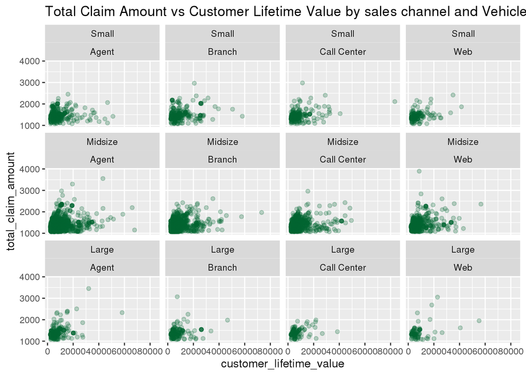

```r
ggplot(auto_claims, aes(x= customer_lifetime_value, y= total_claim_amount))+
  geom_point(alpha=0.25, color = '#006633')+
  facet_wrap(~ vehicle_size + sales_channel)+
  labs(title = "Total Claim Amount vs Customer Lifetime Value by sales channel and Vehicle size")
```

# Problem 4

Use ggplot to create the data visualization below.Width value is 0.07 and the aplha value is 0.1

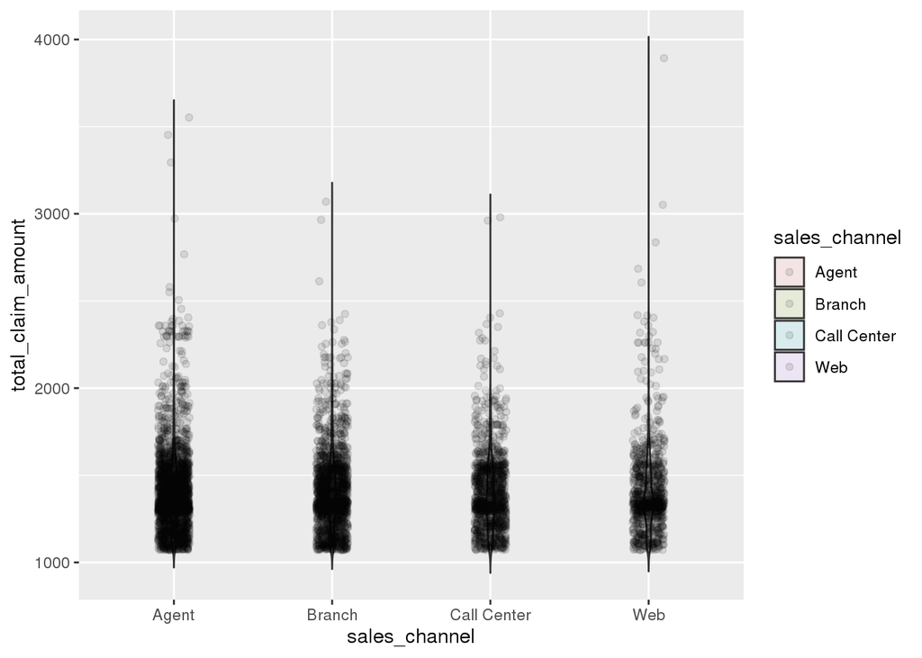

```r
ggplot(auto_claims, aes(x=sales_channel, y=total_claim_amount, fill = sales_channel))+
  geom_violin(alpha = 0.1, width=0.07, trim=FALSE)+geom_jitter(alpha=0.1, position = position_jitter(width=0.1))
```

```r
  labs(title = "violin plot of total claim amount by sales channel")
```

```
## $title
## [1] "violin plot of total claim amount by sales channel"
##
## attr(,"class")
## [1] "labels"
```

# Problem 5

Use `ggplot` to create the data visualization below. The number of bins in the histogram should be set to 15.

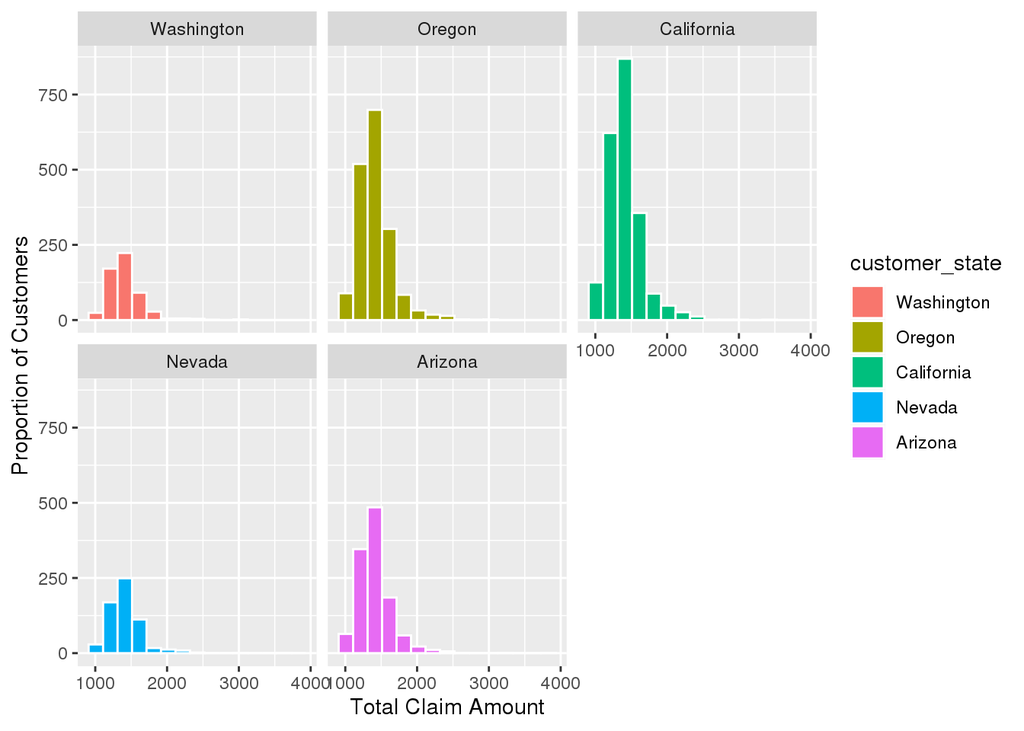

```r
ggplot(auto_claims, aes(x=total_claim_amount, fill=customer_state))+
  geom_histogram(bins=15, color = 'white')+
  facet_wrap(~customer_state)+
  labs( y= 'Proportion of Customers', x = 'Total Claim Amount')
```

# Problem 6

Use `ggplot` to create the data visualization below.

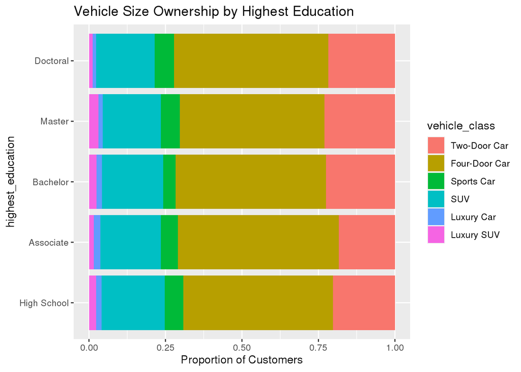

```r
ggplot(auto_claims, aes(y= highest_education, fill = vehicle_class))+
  geom_bar(position="fill")+
  labs(title = 'Vehicle Size Ownership by Highest Education')+
  labs(x = 'Proportion of Customers')
```

--- End of Assignment ---